# IE 582 - Statistical Learning for Data Mining Homework 1

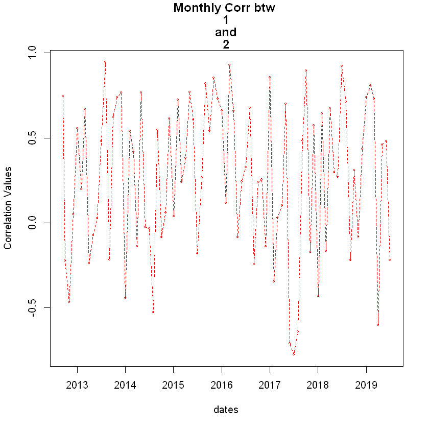

```r
twostockswindow(stockinfo=1,allstocks=1:2,yrs=2012:2019,newmatr[-c(3:5),],dates=p)
```

The function seems to be working perfectly, and the correlation information changes drastically over the consecutive months for AEFES and Aygaz. Further, let me provide two more pairwise correlations and one 3 way correlations with the following indices attached to each respective stock on the graph's title and legend. 1 - AEFES 2 - AYGAZ 3 - TUPRS 4 - SISE 5 - ASELS

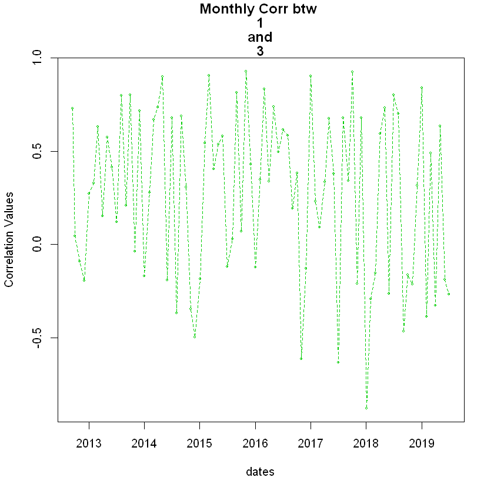

```r
twostockswindow(stockinfo=1,allstocks=c(1,3),yrs=2012:2019,newmatr[-c(2,4,5),],dates=p)
```

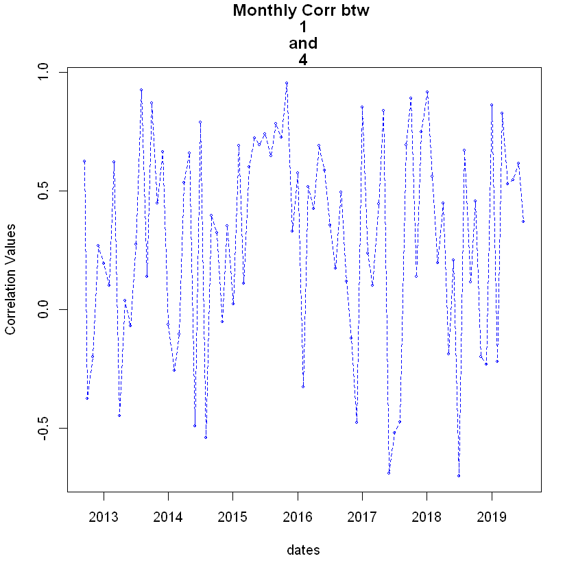

```r
twostockswindow(stockinfo=1,allstocks=c(1,4),yrs=2012:2019,newmatr[-c(2,3,5),],dates=p)
```

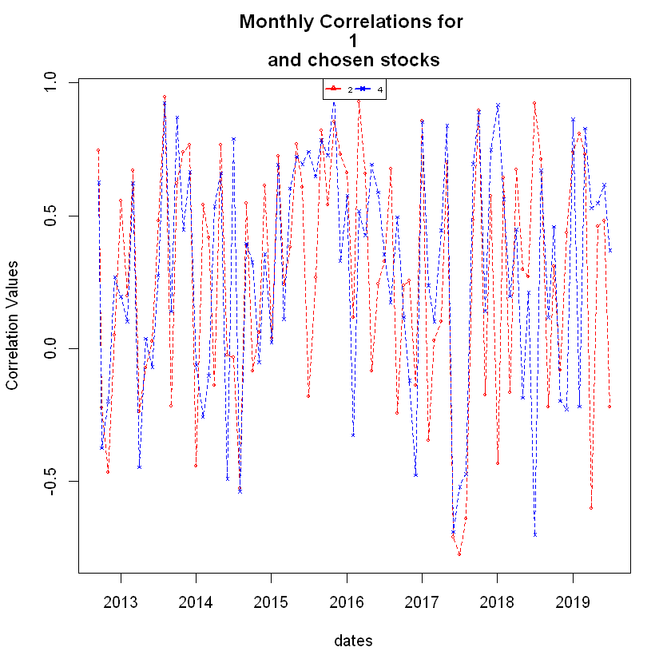

```r
twostockswindow(stockinfo=1,allstocks=c(1,2,4),yrs=2012:2019,newmatr[-c(3,5),],dates=p)
```

This function may be generalized easily with a data generator matrix function but I have not done so because observing interactions with more than one pair seems to be cumbersome and not explanatory.

# Conclusions

We may conclude that the data is not stationary in its raw form, after necessary transformations it may be stationarized to some extent but we are not after time series analysis of a stock price. The correlation information between the stock prices seem to be changing drastically from month to month. However, using the raw form and PCA we were able to capture approximately 94% of the variance using only the first two components produced by the PCA. Further, PCA is an approach that provides one with orthogonal axes, meaning all the components are perpendicular to each other. We create uncorrelated latent variables that are interpretable, linear combination of the other 5 axes. Put in another way, PCA allows us to reduce the noise in the data. It is similar to singular value decomposition, finding orthonormal eigenvectors and associated eigenvalues at which in the end allows us to reconstruct our original matrix by adding up these singular components. Further, in SVD and PCA the eigenvalues are sorted in descending order, meaning the first eigenvector and associated eigenvalue somehow, with an abuse of nomenclature captures the most information regarding our matrix, or data in this setting. Many thanks to Mustafa Hoca for guiding us and teaching us these tools and methodologies. Thanks to İlayda as well.